# Galton’s law of filial regression. Understanding the phenomenon of regression towards the mean

May 15, 2020

## Introduction

Today the most basic data mining tool is the linear regression and, it is often used to compare more complex approaches. The word regression comes from Latin *regressus*, which means “a return”, thus the meaning of the word regression can be interpreted as the act of going back. However, the least of us knows from where the regression comes and how the phenomenon of regression has appeared. We are going to speak about the first study about regression and the main idea of Galton filial regression. For this purpose, the dataset similar to famous Galton data will be used.

[Sir Francis Galton](http://www.galton.org/) was interested in the heredity of human characteristics like personality temperament, artistic ability, and disease incidence, etc. Among all these traits Galton collected information about the human statures[^1] of different families to understand the concept of human height heredity. In his classic paper *“Regression Towards Mediocrity in Hereditary Stature”* he measured the relationship between the heights of children and those of their parents. Galton wanted to know could the height of parents somehow explain/predict the height of the child. For that time the concept of regression, notions like explanatory and dependent variables, noise term did not exist and the knowledge about genetics was limited.

One should think, that the dependence is obvious - tall parents have tall children and vice versa. But, surprisingly, Galton discovered that parents who were taller than average had tall children, but they were not as tall as their parents. And parents with height below the average children were short, but not lower than their parents. So, the height of already adult children deviates to a lesser extent from the average than the height of parents. That is, the children are stronger *regress* to the average.

## About Galton findings

Do you believe that your talent and beauty must be inherited by your children? I hope you do not think so because the statistics are more conservative on this issue. A statistical principle called *“regression to the mean”* will help explain this.

The term **regression** [was coined](https://en.wikipedia.org/wiki/Regression_analysis) by British statistician Francis Galton in the nineteenth century to describe a biological phenomenon. The first studies of Galton referred to the seed size in generations of sweer peas, which he called revision toward the mean. Then, he changed the name of the phenomenon to regression in the mid-1880s after obtaining human data on the heights of parents and their children.

Galton observed that the characteristics of parents are not fully transmitted to their children. The idea of the phenomenon is that the heights of the adult children tend to *regress* toward the mediocre point. And simple linear regression is also called *reversion to the mean* and *reversion to mediocrity*.

Galton found that children of short parents tended to be shorter than average, while children of tall parents tended to be taller than average, *“however, the transmission of height across generations was imperfect.”* This means that the difference between a child and its parents for height is proportional to its parents’ deviation from typical people in the population. In order to find to what extent the heights are inherited across generations Galton uses the principle of regression (without knowing about it) and stated in his article *“the deviates of the children are to those of the mid-parent as 2 to 3”*. So, the child gained only two-thirds of an inch for each inch the parents exceeded the average. Galton concluded that there was **regression towards mediocrity** in height.

To measure the *rate of regression in hereditary stature*, Galton divided the height of offspring into 9 subgroups according to the median height of their two parents. Galton used the median as a measure of central tendency and semi-interquartile range as a measure of variability[^2]. Although this poor choice of descriptive statistics, Galton find the important pattern by plotting the median offspring height against the mid-parent height, and by eye, fitted a straight line to the nine data points.

## About the data

The dataset[^3] was used by Galton in 1885 to study the relationship between the heights in inches of parents and those of their children. The data is represented by a child. Originally, [Galton’s notebook](http://www.medicine.mcgill.ca/epidemiology/hanley/galton/notebook/index.html) lists 963 children in 205 families ranging from 1-15 adult children. 29 of these observations had non-numeric heights recorded. Families are listed in descending order of father, and within these, mother height. The 205 families are identified by the numbers 1-135, 136A, 136-204[^4].

There are different sources and variations of Galton’s initial data. We are going to use the dataset `GaltonFamilies` from the package `HistData` as this data is more comprehensive among others.[^5].

```r
library(HistData)
data("GaltonFamilies")
galton <- GaltonFamilies
dim(galton)
```

```
## [1] 934   8
```

The data set represents the individual observations for 934 adult children in 205 unique families (pair of parents). A data frame consists of following 8 variables.

- family - a family ID variable, as the data include multiple children per family. This is factor variable with 205 unique levels
- father - the height of father
- mother - the height of mother
- midparentHeight - the height of mid-parent (see below)
- children - number of children in the family
- childNum - ID of children in the family
- gender - the gender of child
- childHeight - the child’s height

From the graphs below, we can see that the distributions of parent’s and child’s height can be approximated by the normal distribution. It is important because Galton findings is true when variables follow a normal distibution.

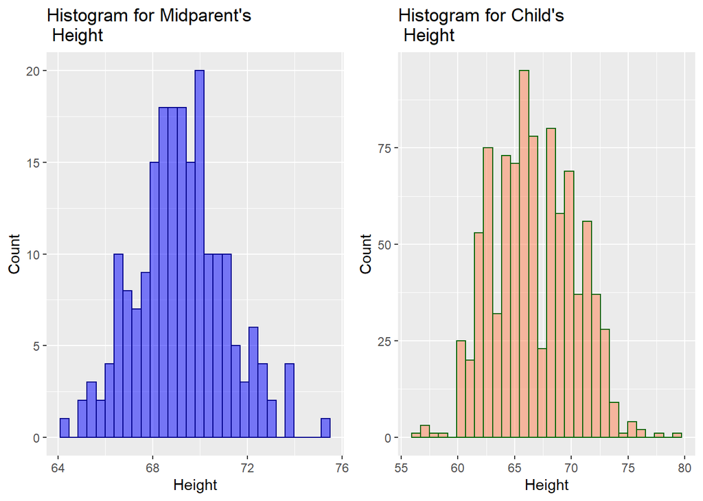

```r
g1 <- galton %>%
  group_by(family) %>%
  sample_n(1)%>%
  ungroup() %>%
  ggplot(aes(midparentHeight))+
  geom_histogram(col = "darkblue", fill = "blue", alpha = 0.5) +
  labs(title="Histogram for Midparent's \n Height", x="Height", y="Count")

g2 <- galton %>%
  ggplot(aes(childHeight))+
  geom_histogram(col = "darkgreen", fill = "coral", alpha = 0.5) +
  labs(title="Histogram for Child's \n Height", x="Height", y="Count")

ggarrange(g1,g2)
```

Suppose we want to understand do tall fathers have tall kids or do tall mothers have tall kids. The simple visualization below shows that there are positive relationships between the *average* height of kids in a family and their fathers’ and mothers’ heights.

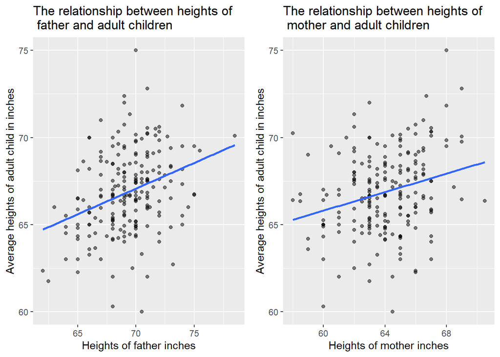

When regressing the heights of adult children on those of their parents, Galton took into consideration the fact that in general men are taller than women. In order to adjust the height in his analysis Galton multiplied female heights by 1.08. He *transmuted* the height of females and then defined the term *mid-parent* which is an average of the father’s height and the transmuted mother’s height.

```r
all(galton$midparentHeight == (galton$father+1.08*galton$mother)/2)
```

```
## [1] TRUE
```

Galton applied the process of adjusting the heights of women to the height of each daughter, too.

```r
galton$childHeight2 <- ifelse(galton$gender=="female", galton$childHeight *1.08, galton$childHeight)
```

Now, let’s understand how Galton came to the ideo of regression.

## Understanding Galton’s findings

To describe the main concept of regression let’s look at the following subcase. Without knowing the mid-parental height the best guess for a child height, probably, would be the simple average height of all children.

```r
mean(galton$childHeight)
```

```
## [1] 66.74593
```

However, what if the mid-parental height of this child is greater than average? Is still the guess of the mean for the child good one? So, in that case, the conditional expectation will be the better prediction for the height of the child.

```r
galtonUnique <- galton %>%
  group_by(family) %>%
  sample_n(1)%>%
  ungroup()

# Mean of mid-parental height
galtonUnique %>%
  summarise(mean = mean(midparentHeight))%>%
  pull()
```

```
## [1] 69.2191
```

However, for any specific value of mid-parental height (for example 67.4) we will have a very little number of data points.

```r
galtonUnique%>%
  filter(midparentHeight == 67.400)
```

```
## # A tibble: 2 x 9
##   family father mother midparentHeight children childNum gender childHeight
##   <fct>   <dbl>  <dbl>           <dbl>    <int>    <int> <fct>        <dbl>
## 1 093        70     60            67.4        4        4 female          63
## 2 094        70     60            67.4        2        1 female          65
## # ... with 1 more variable: childHeight2 <dbl>
```

The usage of rounding to the nearest inch can help to solve this issue:

```r
galtonUnique %>%
  filter(round(midparentHeight) == 67) %>%
  dim()
```

```
## [1] 22  9
```

Now we can predict the height of a child calculating the average of this subgroup.

```r
galton %>%
  filter(round(midparentHeight) == 67) %>%
  summarise(mean = mean(childHeight)) %>%
  pull()
```

```
## [1] 65.53563
```

Note that 67-inch midparent is shorter than the average (overall mean is 69.2, mean for 67-inch group is 66.9), and the prediction for child height is lower than average (overall mean 67, average of 67-inch group 65.5), but the deviation from the average for midparent is larger. Galton said that children have **regressed** to average height.

As Galton suggested, let’s consider the means of the groups and plot it against the divided groups:

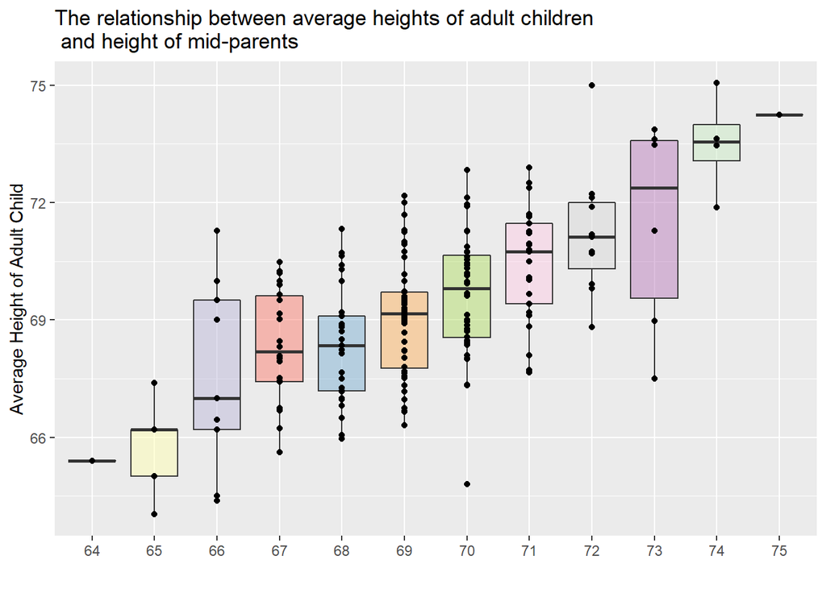

```r
galton %>%
  mutate(group = factor(round(midparentHeight)))%>%
  group_by(family)%>%
  summarise(Avg_Child = mean(childHeight2), group = mode_my(group)) %>%
  ungroup()%>%
  ggplot(aes(group, Avg_Child, fill = group)) +
  geom_boxplot(alpha = 0.5 ) +
  geom_point() +
  scale_fill_brewer(palette="Set3") +
  theme(legend.position = "None") +
  xlab("") + ylab("Average Height of Adult Child")+
  ggtitle("The relationship between average heights of adult children \n and height of mid-parents")
```

The median of boxplots is similar to the points of Galton’s famous plot. And this is the main idea of his study. Galton simply divided the height of parents, created groups, calculated the mediocre point of children’s height for each group and plot in on the graph. When he noticed some patterns between these points and the height of mid-parents. To construct the Galtont’s Table 1 (joint distribution of the heights of mid-parents and their adult children) and Plate X, which are first steps for simple linear regression, let’s do some transformation with the data:

```r
# Grouping the mid-parental height and height of children just as Galton had done
galton$midgroup <- factor(round(galton$midparentHeight))
galton$childgroup <- factor(round(galton$childHeight2))

# Contracting crosstabs
tab <- as.data.frame.matrix(table(galton$midgroup, galton$childgroup))[12:1,]
tab[2,] <- colSums(tab[1:2,])
tab <- tab[2:12,] #>74

tab[,3] <- rowSums(tab[,1:3])
tab <- tab[,3:18] #<63

tab[,12] <- rowSums(tab[,12:16])
tab <- tab[,1:12] #>74

# Calculating the total number of adult children
tab$adultChind <- rowSums(tab)

# Calculating the total number of mid-parents
midpar <-NULL

for(i in 64:75){

  midpar[i-63] <- galton%>%
  filter(midgroup == i)%>%
  group_by(family)%>%
  summarise(n=n())%>%
  pull()%>% length()

}

midpar <- midpar[12:1]
midpar[2] <- sum(midpar[1:2])
tab$midparent  <- midpar[2:12]

# Calculating the total by row
tab[12,] <- colSums(tab)
rownames(tab)[12] <- "Total"

# Calculating the mean of child height by family groups
meanchildHeight <- NULL

for(i in 64:75){

  meanchildHeight[i-63] <- galton%>%
  filter(midgroup == i)%>%
  summarise(mean=mean(childHeight2))%>%
  pull()

}

meanchildHeight <- meanchildHeight[12:1]
meanchildHeight[2] <- galton%>%
  filter(midgroup == 75|midgroup == 74)%>%
  summarise(mean=mean(childHeight2))%>%pull()
tab$Mean <- c(meanchildHeight[2:12],NA)
```

```r
options(knitr.kable.NA = '')
kable(tab, "html", booktabs = T)%>%
  kable_styling(bootstrap_options = "striped", full_width = F) %>%
  column_spec(1, bold = T, italic = T, width = "5cm") %>%
  row_spec(12, bold = T, italic = T) %>%
  add_header_above(c("Heights of the Mid-parents in inches" = 1, "Heights of the Adult Children" = 12, "Total Number of" = 2, " " = 1)) %>%
  add_header_above(c(" ", "Number of Adult Children of various height of 205 Mid-parents of various heights" = 15), bold = T, italic = T) %>%
  footnote(symbol = c("Note that in Galton table there must be a mistake in the first row of total number of mid-parents (there are 4 children an 5 mid-parent).", "The recoding of heingt has done based on the nearest integer."))
```

| Heights of the Mid-parents in inches | Number of Adult Children of various height of 205 Mid-parents of various heights Heights of the Adult Children Below | Number of Adult Children of various height of 205 Mid-parents of various heights Heights of the Adult Children 64 | Number of Adult Children of various height of 205 Mid-parents of various heights Heights of the Adult Children 65 | Number of Adult Children of various height of 205 Mid-parents of various heights Heights of the Adult Children 66 | Number of Adult Children of various height of 205 Mid-parents of various heights Heights of the Adult Children 67 | Number of Adult Children of various height of 205 Mid-parents of various heights Heights of the Adult Children 68 | Number of Adult Children of various height of 205 Mid-parents of various heights Heights of the Adult Children 69 | Number of Adult Children of various height of 205 Mid-parents of various heights Heights of the Adult Children 70 | Number of Adult Children of various height of 205 Mid-parents of various heights Heights of the Adult Children 71 | Number of Adult Children of various height of 205 Mid-parents of various heights Heights of the Adult Children 72 | Number of Adult Children of various height of 205 Mid-parents of various heights Heights of the Adult Children 73 | Number of Adult Children of various height of 205 Mid-parents of various heights Heights of the Adult Children Above | Number of Adult Children of various height of 205 Mid-parents of various heights Total Number of Adult Children | Number of Adult Children of various height of 205 Mid-parents of various heights Total Number of Mid-parents | Number of Adult Children of various height of 205 Mid-parents of various heights Mean |
| --- | --- | --- | --- | --- | --- | --- | --- | --- | --- | --- | --- | --- | --- | --- | --- |
| Above | 0 | 0 | 0 | 0 | 0 | 0 | 1 | 0 | 3 | 1 | 7 | 11 | 23 | 5 | 73.43461 |
| 73 | 0 | 0 | 0 | 0 | 2 | 1 | 0 | 0 | 3 | 2 | 4 | 4 | 16 | 6 | 72.18000 |
| 72 | 0 | 0 | 0 | 0 | 2 | 2 | 6 | 9 | 7 | 6 | 5 | 3 | 40 | 11 | 70.86770 |
| 71 | 1 | 0 | 1 | 2 | 3 | 10 | 11 | 21 | 21 | 17 | 7 | 7 | 101 | 25 | 70.52943 |
| 70 | 1 | 1 | 7 | 9 | 12 | 38 | 22 | 57 | 29 | 21 | 15 | 9 | 221 | 40 | 69.75538 |
| 69 | 1 | 1 | 11 | 28 | 24 | 40 | 42 | 43 | 27 | 25 | 10 | 2 | 254 | 52 | 68.95554 |
| 68 | 2 | 2 | 6 | 15 | 20 | 26 | 18 | 22 | 13 | 5 | 2 | 0 | 131 | 29 | 68.31502 |
| 67 | 2 | 5 | 4 | 5 | 13 | 21 | 13 | 15 | 4 | 4 | 1 | 0 | 87 | 22 | 68.09628 |
| 66 | 2 | 4 | 6 | 5 | 3 | 3 | 2 | 4 | 1 | 1 | 0 | 1 | 32 | 9 | 66.84250 |
| 65 | 3 | 0 | 5 | 6 | 6 | 5 | 1 | 1 | 0 | 0 | 0 | 0 | 27 | 5 | 66.21185 |
| 64 | 0 | 0 | 1 | 1 | 0 | 0 | 0 | 0 | 0 | 0 | 0 | 0 | 2 | 1 | 65.40000 |
| Total | 12 | 13 | 41 | 71 | 85 | 146 | 116 | 172 | 108 | 82 | 51 | 37 | 934 | 205 |  |

* Note that in Galton table there must be a mistake in the first row of total number of mid-parents (there are 4 children an 5 mid-parent).  
† The recoding of heingt has done based on the nearest integer.

Note that both the total number of mid-parents and their children are approximately normal. Galton showed that if two variables follow a bivariate normal distribution, the prediction computing via conditional expectation and the regression line is reciprocal.

From table above, corresponding to mid-parents of given height we calculated the mean height of the children (the last column). These mean values are plotted against mid-parental height. Galton fitted a straight line through the points by eye and found that its slope was 2/3. We will check it by considering the linear regression model (see below). He expressed this in a chart showing the rate of regression in hereditary stature.

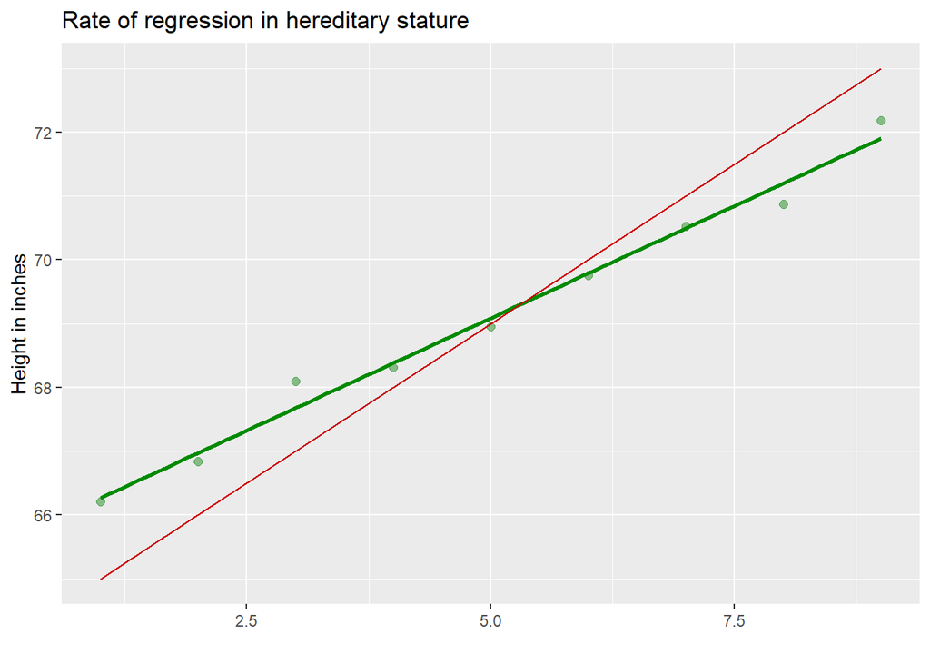

```r
ggplot(tab[2:10,], aes(x=9:1, y = Mean))+
  geom_point(alpha = 0.5, col = "forestgreen", size = 2)+
  geom_smooth(method = "lm", se = F, col = "green4") +
  geom_line(mapping = aes(x=c(1:9), y=65:73), col = "red3") +
  xlab(" ") +
  ylab("Height in inches") +
  ggtitle("Rate of regression in hereditary stature")
```

### The regression and correlation

Now, when we all know about the concept of regression it is quite simple to predict the values of the dependent variable using the value of the explanatory variable and the fitted line. The simple linear regression line has the following representation:

$Y=\beta_0+\beta_1 x$

Based on the obtained coefficient estimation using OLS the above equation can be rewritten as:

$\dfrac{Y - \bar{Y}}{s_y} = \rho \dfrac{x - \bar{x}}{s_x}$

If we have imperfect correlation (a.k.a apart from 0 and 1)[^6] linear regression is the appropriate model for this data. Even Galton used estimated correlation coefficient, he recognized the important relationship between the paired variables $y=\rho \frac{s_y}{s_x} x$. Note that, differences in variability between the two variables influence the slope of the regression line but not the level of association between the variables.[^7] From the formula above, if we standardize the variables, the regression line has intercept 0 and slope equal to the correlation $\rho$. Galton’s find a slope of 0.66, which indicated to him that extremely large or small mother seeds typically generated less extreme daughter seeds.

In the Galton studies, the angle formed between the least-squares regression line and the positive direction of the x-axis is approximately $34^\circ$. Galton determined their estimate of the regression coefficient by comparing the tangent of this angle to the tangent of $45^\circ$. That is $tan(34^\circ):tan(45^\circ) \approx 2:3$. According to Galton, the law of regression can be defined in the following way: “The height-deviate of the offspring is, on the average, two-third of the height-deviate of its mid-parentage”. The same result is derived using the linear regression model below:

```r
galton %>%
  group_by(family) %>%
  summarise(Avg_child = mean(childHeight2), mid_par =    mean(midparentHeight))%>%
  ungroup()%>%
  lm(formula = Avg_child~mid_par) %>%
  summary()
```

```
##
## Call:
## lm(formula = Avg_child ~ mid_par, data = .)
##
## Residuals:
##     Min      1Q  Median      3Q     Max
## -5.0796 -1.0946 -0.0191  1.0156  4.2707
##
## Coefficients:
##             Estimate Std. Error t value Pr(>|t|)
## (Intercept) 22.98986    3.97734    5.78 2.78e-08 ***
## mid_par      0.66909    0.05744   11.65  < 2e-16 ***
## ---
## Signif. codes:  0 '***' 0.001 '**' 0.01 '*' 0.05 '.' 0.1 ' ' 1
##
## Residual standard error: 1.57 on 203 degrees of freedom
## Multiple R-squared:  0.4006, Adjusted R-squared:  0.3977
## F-statistic: 135.7 on 1 and 203 DF,  p-value: < 2.2e-16
```

Although Galton could not analytically derive the coefficient of regression he used geometrical proof - contours of equal bivariate frequencies in the joint distribution which looked like an ellipse. The data ellipse is a useful data visualization technique in analyzing bivariate data which adds a visual summary to a scatterplot. It shows the means, standard deviations, correlation and slope of the regression line.

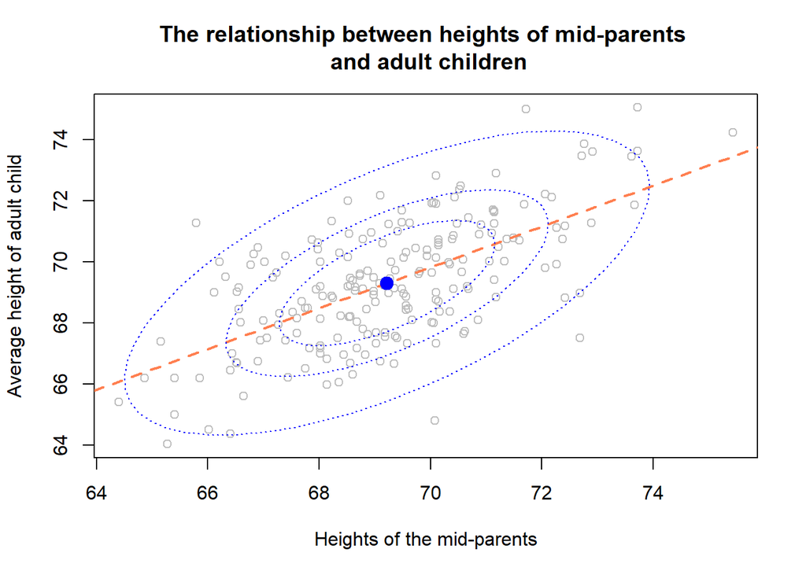

```r
with(galton %>%
  group_by(family) %>%
  summarise(Avg_child = mean(childHeight2), mid_par =   mean(midparentHeight))%>%
  ungroup(), {
    plot(mid_par,Avg_child, xlab = "Heights of the mid-parents", ylab = "Average height of adult child", col = "grey")
    abline(lm(Avg_child ~ mid_par), col="coral", lty= 2, lwd = 2)
    title("The relationship between heights of mid-parents \n and adult children")
    if(require(car)){dataEllipse(mid_par,Avg_child, plot.points=FALSE, levels=c(0.4, 0.68, 0.95),lwd =1, lty = 3 )}})
```

The overlayed data ellipses have the mean vector $(\bar{x}, \bar{y})$ as their center. Projections of ellipsis on coordinate axes give the standard deviations of the variables ($\bar{x} \pm ks_x$ and $\bar{y} \pm ks_y$, with ($k=1, 1.5, 2.45$)), having bivariate coverage 40%, 68% and 95% and univariate coverage 68%, 87% and 98.6%, respectively. As Galton noted, the regression line can be visually estimated as the locus of the points of vertical tangents with the family of concentric ellipses.

Now, let’s consider how ellipses helped Galton to understand regression and the relationship between these variables.

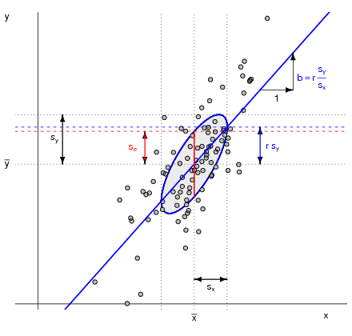

According to “Elliptical Insights” of Friedly, Monette, and Fox:

- One-half of the widths of the vertical and horizontal projections give the standard deviations of variables.
- With a bivariate normal distribution, the line-segment through the center of the ellipse shows the mean and standard deviation of the conditional distribution on that line.
- The standard deviation of the residuals can be visualized as the half-width of the vertical line.
- The vertical distance between the mean of y and the points where the ellipse has vertical tangents is $r s_y$.
- The regression line of y on x passes through the points of vertical tangency.

## Conclusion

Overall, if the data is approximately bivariate, then the conditional expectation can be obtained using the regression line. The idea behind the regression toward the mean is that, following an extreme random event, the next random event is likely to be less extreme․ Galton found that children of short parents tended to be shorter than average, while children of tall parents tended to be taller than average, *" however, the transmission of height across generations was imperfect."*

Although Galton uses the mid-parental height and did not pay attention to the gender of children, he wrote that “the height of daughters, takes after the height of the father more than it does after the of the mother”. Han, Ma, and Zhu challenged whether Galton’s classic model and its interpretation are proper. In their study, you can find the consideration of gender-specific models with different regression fits and drawbacks in Galston’s study. Also, you can find the [shiny app](http://www.biostat.mcgill.ca/hanley/galton/GaltonsHeightForecaster.zip) which shows how to predict the child heigh having mid-parental height.

There are the different paper with criticism of Galton findings which refers to incorrectness of biological explanation for the regression phenomenon, the inappropriateness of Galton’s calculation of mid-parental height, the abstraction from the gender of the child, a fixed correlation of characteristics across generations. However, these mistaken assumptions gave us the notion and idea of regression and the conceptual difference between the correlation and regression.

## Refference list

> Francis Galton “Regression Towards Mediocrity in Hereditary Stature”. The Journal of the Anthropological Institute of Great Britain and Ireland, Vol. 15 (1886), pp 245-263

> James A. Hanley “‘Transmuting’ Women into Men: Galton’s Family Data on Human Stature”. The American Statistician Vol. 58, No. 3 (Aug., 2004), pp. 237-243

> Hao Han, Yeming Ma, and Wei Zhu “Galton’s Family Heights Data Revisited” (Aug 2015)

> Kurt Benirschke “Francis Galton: Pioneer of Heredity and Biometry”. Journal of Heredity, Vol. 95, Issue 3, (May 2004), p. 273

> Michael Friendly, Georges Monette and John Fox “Elliptical Insights: Understanding Statistical Methods through Elliptical Geometry”. Statistical Science (Feb 2013), Vol. 28, No. 1, pp 1-39
[^1]: You can find the advantages of choosing this feature in Galton paper. The main advantages, as he wrote, is the ease and frequency of measurement, constancy, height is the sum of the accumulated lengths of body parts, etc. As a disadvantage, Galton noted the small variability of stature.
[^2]: We use the sample mean and standard deviation because of their mathematical properties.
[^3]: Karl Pearson’s early work relied on these family data.
[^4]: Note that the digital version of the original data is incomplete, for full dataset the hard copy should be used.
[^5]: It is also available in the `UsingR` package of Verzani (2005), `RSADBE` package of Tattar (2013) which contain the similar data. Besides, the `HistData` package contains dataset `Galton` with only two variables.
[^6]: In case of $\rho = 1$, we will have the increase that is the same number if standard deviation, and in case of $\rho = 0$ the prediction for $y$ will be its mean value.
[^7]: To see the visual and numeric explanation of the difference between regression coefficient and the association between the variables [follow the link.](https://amstat.tandfonline.com/doi/full/10.1080/10691898.2001.11910537#.XjEiAGgzb4Y)